# ChemHealth

Miao YU

2014/10/13

# Chemicals in our environment: What is a chemical, and how are we exposed?

## Chemical defination

- A compound or substance that has been purified or prepared, especially artificially

## How Populations Are Exposed to Chemicals

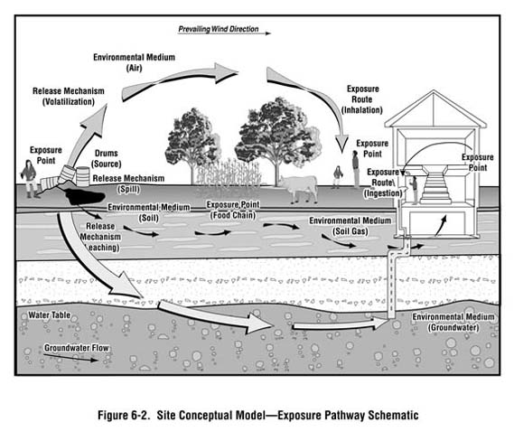

## How Chemicals Get into Our Bodies

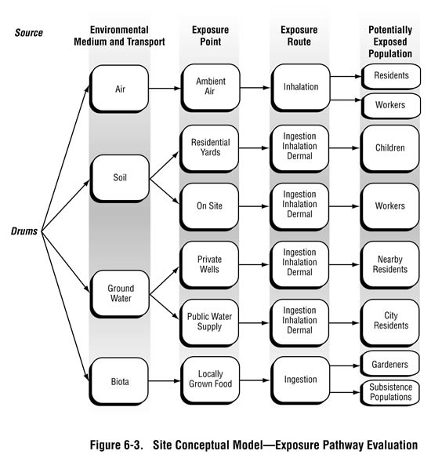

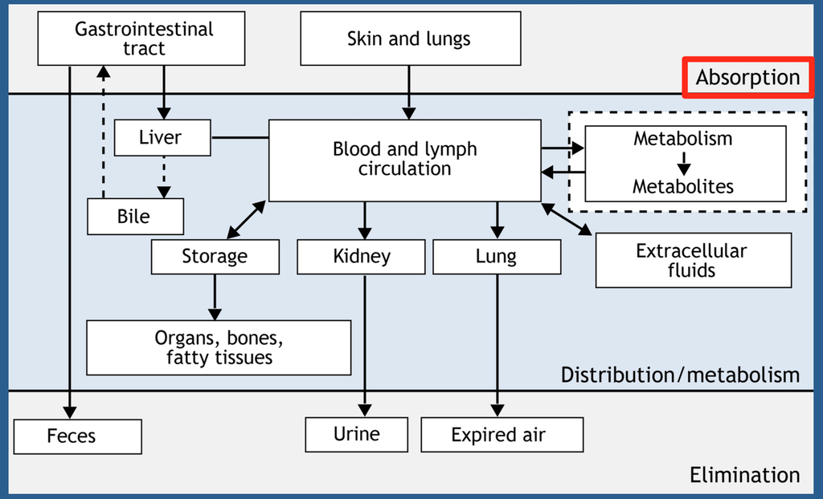

[figure not shown]

## Database

- [IRIS: Integrated Risk Information System (EPA)](http://www.epa.gov/iris/)
- [HazDat Database and ToxFAQ (ATSDR)](http://www.atsdr.cdc.gov/)
- [TOXNET: National Library of Medicine](http://toxnet.nlm.nih.gov/)
- [MSDS: Materials Safety Data Sheets](http://www.ccohs.ca/oshanswers/legisl/msdss.html)

## The Chemical Industry Work Environment

## Occupational Health: Understanding and Assessing Exposures and Outcomes

- Occupational Health Surveillance
- Exposure Assessment
- Occupational Epidemiology Study Designs
  - Cohort: a designated group of individuals who are identified as eligible for the study, subject to further inclusion factors, in order to evaluate factors associated with adverse health outcomes
  - no random selection of individuals into the cohort
  - Cohort studies can be prospective or retrospective
- What Is the Healthy Worker Effect?
  - Observation that workers exhibit lower mortality rates than the general population
  - Selection of “healthier” persons into the workforce
  - Retention of “healthier” persons in the workforce
  - In appropriate comparison population that differs in terms of Vital status ascertainment Differential diagnoses Risk factors for mortality Access to treatment

## Industrial Hygiene Practices

## Regulatory Programs and Initiatives

# Toxicology: What do chemicals do in our bodies?

## Intro to Chemicals and Health

- Toxicology: the study of poisons
- Poisons: chemical or physical substances which produce adverse responses in biological organisms
- Toxicants: toxic substances that are either manmade or result from human activity
- Toxins: usually toxic substances produced by living organisms, such as reptiles, insects, plants, and microorganisms

> “The dose makes the poison” — Paracelsus

## Processes Involved in Chemical Toxicity

- Exposure is outside the body
- After absorption, you have an internal dose
- Distribution mainly through blood
  - Biotransformation
  - Elimination
  - Storage
    - Fat (lipid-soluble)
    - Bone (minerals)
- The end result of these toxicokinetic processes is a biologically effective dose (BED) of the toxicant
- The biologically effective dose is that portion of the internal dose that interacts with biological molecules (targets)
  - Leads to changes in cells
    - Molecular
    - Biochemical changes
  - Cell toxicity
  - Organ dysfunction/disease
- The effect depends on the dose of the agent
- Toxicokinetics: (movement) processes that the body subjects the chemical to
  - Absorption: taking in of a chemical from a site(s) of exposure (i.e., gastrointestinal system) resulting in an internal dose
  - Distribution: distributing a chemical from its site of absorption throughout the body
  - Excretion/elimination: removing the chemical from the body
  - Biotransformation/metabolism: modification of chemicals by enzymes in the body
- Toxicodynamics: (changes) what the chemical does to the organism, Toxicodynamics refers to the effects of toxicants (or their metabolites) in biological systems
  - Some interactions with target molecules result in an adverse biological effect, while others may not
  - For some chemicals, the form that interacts with targets is the original chemical
  - For other chemicals, the toxic form is a biotransformation product(s) of that chemical

# Biomonitoring: How do we measure chemicals in our bodies and why?

## Exposure Assessment Approaches

- Questionnaire/historical information
- Environmental monitoring
- Personal monitoring
- Biomonitoring
- Combine these approaches with calibrated and validated models

## Biomonitoring

- A useful tool for exposure assessment
- Defined as the assessment of internal dose by measuring the parent chemical (or its metabolite or reaction product) in human specimens (for example: blood, urine)
- Measurement of concentrations, not exposures

## Evaluation of Human Exposure Using Biomonitoring

- Large–scale population surveys
  - NHANES: provides a foundation for CDC’s National Biomonitoring Program
- Epidemiological studies of specific populations
  - Susceptible/vulnerable
  - Highly exposed (for example: NICU infants, occupational settings)

## Considerations in Biomonitoring

- What is the best chemical measure (analyte)?
  - Parent chemical or metabolite or adduct
- What is the best time to obtain the specimen?
  - Measurement time windows
- What is the best specimen (matrix)?
  - Blood and urine
- Analytical considerations
  - Related to the specimen (for example: stability, contamination, interferences, etc.)
  - Related to the method (for example: validated method, sensitivity, specificity, QA/QC, etc.)

## NHANES: How We Assess Exposure of the US Population to Priority Environmental Chemicals

- Began in 1971
- Continuous survey since 1999 (survey cycle = two years)
- Stratified, multistate national probability sample
- About 10,000 participants in 30 locations every two years
- method
  - Face-to-face and computer-assisted interviews:Demographics, Socioeconomic, Dietary,Health-related topics
  - Physical examination
  - Biological specimen collection
  - More at: http://www.cdc.gov/nchs/nhanes/about_nhanes.htm
- Not all chemicals are measured in everyone, except:Blood Pb, Cd, and Hg: all persons one year and older, Serum cotinine: all persons three years and older
- Most urinary chemical measurements are made in a 1/3 subsample of the participants, Ages six years and older,Subsamples are determined so they are representative of the US population
- Biomonitoring results are presented in the National Report on Human Exposure to Environmental Chemicals
- [DATA](http://www.cdc.gov/exposurereport/)
- Chemical properties (for example: persistence in the body, metabolism, stability) and analytical considerations are factors in biomarker selection and specimen collection
- Detection of a chemical does not mean that it causes disease

## Biomonitoring at the state and local laboratories

- CDC’s data can not be used at the state & local level
- [APHL. Public health laboratories](http://www.aphl.org/aboutaphl/aboutphls/pages/default.aspx)

# Health effects of chemicals: How do we figure out how chemicals affect our health?

## Discuss different types of health effects

- Acute vs latent
- Transient vs chronic
- Beneficial vs adverse

## Describe various health endpoints

- Acute toxicity
  - Generally related to short-term exposure,severeeffects
  - Example:carbonmonoxidepoisoning
  - Can have short-term and long-term consequences
- Repeated dose toxicity -Depends on toxicokinetics(what happens to the toxin in the body, and how quickly)
  - Effects could be acute(threshold),subacute,orchronic
  - Example: some medications build up effects(e.g.,acetaminophen)
- Genotoxicity
  - Some chemicals can damage DNA, causing mutations when the cells divide
  - These mutations can lead to cancer if the cells are in not reproductive(eggorsperm) cells, or to some birth defects
- Carcinogenicity
  - Ability to cause cancer or make cancer more likely
  - Can be director in direct effects
  - Most chemicals that have been identified as likely carcinogens have been from animal studies; fewer from direct human epidemiology
  - Occupational workers most likely to be exposed; examples are coke oven workers, asbestos workers
- Reproductive toxicity
  - Reproduction is complex, and process can be interrupted at many points
  - Some effects from direct toxicity to egg or sperm cells, other effects on developing
  - Difficult to identify in people; most identified in animal models fetus
- Endocrine disruption
  - Relatively recent findings of chemicals mimicking naturally occurring hormones such as sex hormones
  - Possible links to development, maturation, sexual maturation
  - Early in our understanding
- Neurotoxicity: general,delayed
  - Effect on developing or mature nervous system
  - Effects on central nervous system including cognition(lead), peripheral nervous system
- Other: immunotoxicity, allergenicity, intolerance
- Toxicity endpoints
- [National Environmental Health Tracking Network](http://ephtracking.cdc.gov)
- Causal association: Hill’s Causal Criteria

## Risk Assessment in Environmental Decision Making

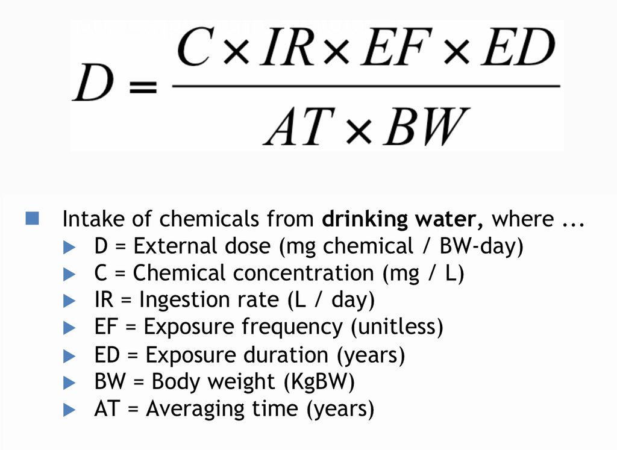

- Risk Characterization
  - Integration of information from hazard identification, dose-response evaluation, and exposure assessment steps
  - A risk characterization often includes …
    - Prediction of carcinogenic risks and potential for non-carcinogenic hazard
    - Estimation of population burden (cancer)
    - Uncertainty discussion
  - Quantitative Risk Characterization
    - Risk of 1 x 10e-6 is “one case per million persons exposed over a lifetime”
  - Risk = exposed dose × effect unitless
  - No. cases = risk × population size
  - The outputs of a risk assessment typically include an estimate of cancer risk, non- cancer hazard, population cancer burden, and an uncertainty discussion

# Chemicals policy: What do we do about chemicals and health?

## Toxic Substances Control Act

- Covers most chemicals used in industry and in commercial/consumer products
- Excludes:
  - Uses in drugs, cosmetics, food, and food packaging regulated by FDA
  - Uses in pesticides covered by EPA under FIFRA
- Basic provisions have never been amended
- Chemical Policy
  - Legislation
  - Regulation
  - Court decisions (“case law”)

## Drivers for Chemical Policy Reform

- Chemicals Are Ubiquitous
  - 10 trillion pounds produced per year in the US
  - Used to make 96% of all materials and products
  - Large but unknown number of chemicals in US commerce
- Science Drivers: Connecting the Dots
  - Certain chronic diseases are on the rise
  - Certain chemicals are linked to those same chronic diseases
  - Many of those same chemicals are in us
- Diseases Linked to Chemical Exposures
  - Cancer
  - Learning and developmental disabilities
  - Parkinson’s and Alzheimer’s disease
  - Reproductive health and fertility problems
  - Asthma
  - Diabetes
  - Obesity
  - Immune disorders
  - Cardiovascular disease
- Understanding of extent and pathways of chemical exposures
  - Long-range transport
  - Migration of chemicals from products into environment
  - Disproportionate exposures: environmental justice issues
  - Advent of biomonitoring
  - Early-life exposures
- Risk assessment evolution and controversy
- “RedBook”(1983),and a major update “SilverBook”(2009)
- Key challenges: Human variability, Uncertainty, Cumulative effects and exposures(Multiple chemicals, Chemicals and other stressors)
- Emerging high-throughput testing: Tox21

## Why Legislative Reform?

- New chemicals
  - No data, no problem
  - Guessing game
  - Catch-22
  - Anti-precaution
- Why Now?
  - State legislation and policy changes
  - Top priority of last two EPA administrators
  - Market demand, especially from downstream users
  - Retail regulation
  - European Union’s REACH Regulation and Canadian Environmental Protection Act
- REACH
  - “No data,no market”
  - Shifting the burden of proof: Industry required to show safety
  - Information flow in supply chains: Two-way flow between suppliers <–> customers
  - Authorization required to use substances of very high concern
- Action
  - [EDF](http://www.edf.org/health/policy/chemicals-policy-reform)
  - [EDF Health blog](http://blogs.edf.org/health/)